```python
# import packages
# Data Manipulation
import pandas as pd
import numpy as np

# To plot the graphs
import matplotlib.pyplot as plt
import seaborn as sns
from matplotlib.pyplot import figure

# Import Random Forest Classifier
from sklearn.ensemble import RandomForestClassifier

# Classification report and accuracy score
from sklearn.metrics import classification_report
from sklearn.metrics import accuracy_score

# Import warnings and add a filter to ignore them
import warnings
warnings.simplefilter('ignore')

# Import XGBoost
import xgboost

# XGBoost Classifier
from xgboost import XGBClassifier

# Confusion matrix
from sklearn.metrics import confusion_matrix

# Cross validation
from sklearn.model_selection import KFold
from sklearn.model_selection import cross_val_score

# Pandas datareader to get the data
from pandas_datareader import data
```

# Data Collection

Since we are going to sacrifice some dataset during training the data, we are going to collect the relevant gold price and bitcoin price from the same source as given in the problem.

For Gold, we collected the price from 2016-1-1 to 2016-10-1 `Source: London Bullion Market Association.`

For Bitcoin, we collected the price also from 2016-1-1 to 2016-10-1 `Source: NASDAQ`

```python
# Gold (From our collection)
df_gold_prev = pd.read_excel('lbma_gold_pm.xlsx', header = 1)
df_gold_prev = df_gold_prev.rename({'PM': 'gold'}, axis = 1)
df_gold_prev = df_gold_prev.rename({'DATE': 'Date'}, axis = 1)
df_gold_prev['Date'] = pd.to_datetime(df_gold_prev['Date'])
df_gold_prev = df_gold_prev.iloc[15:, :]
df_gold_prev
```

|  | Date | gold |
| --- | --- | --- |
| 15 | 2016-09-09 | 1330.85 |
| 16 | 2016-09-08 | 1343.40 |
| 17 | 2016-09-07 | 1348.35 |
| 18 | 2016-09-06 | 1337.25 |
| 19 | 2016-09-05 | 1326.35 |
| ... | ... | ... |
| 185 | 2016-01-08 | 1101.85 |
| 186 | 2016-01-07 | 1106.35 |
| 187 | 2016-01-06 | 1091.40 |
| 188 | 2016-01-05 | 1077.00 |
| 189 | 2016-01-04 | 1082.25 |

175 rows × 2 columns

```python
# Open Gold dataset and merge with the previous one
df_gold = pd.read_csv('LBMA-GOLD.csv')
df_gold = df_gold.rename({'USD (PM)': 'gold'}, axis = 1)
df_gold['Date'] = pd.to_datetime(df_gold['Date'])
df_gold.head()
```

|  | Date | gold |
| --- | --- | --- |
| 0 | 2016-09-12 | 1324.60 |
| 1 | 2016-09-13 | 1323.65 |
| 2 | 2016-09-14 | 1321.75 |
| 3 | 2016-09-15 | 1310.80 |
| 4 | 2016-09-16 | 1308.35 |

```python
# Merge two dataframes
df_gold = pd.concat([df_gold_prev, df_gold])
df_gold
```

|  | Date | gold |
| --- | --- | --- |
| 15 | 2016-09-09 | 1330.85 |
| 16 | 2016-09-08 | 1343.40 |
| 17 | 2016-09-07 | 1348.35 |
| 18 | 2016-09-06 | 1337.25 |
| 19 | 2016-09-05 | 1326.35 |
| ... | ... | ... |
| 1260 | 2021-09-06 | 1821.60 |
| 1261 | 2021-09-07 | 1802.15 |
| 1262 | 2021-09-08 | 1786.00 |
| 1263 | 2021-09-09 | 1788.25 |
| 1264 | 2021-09-10 | 1794.60 |

1440 rows × 2 columns

```python
# Bitcoin (From our collection)
df_bit_prev = pd.read_csv('BTC-USD.csv')
df_bit_prev = df_bit_prev.rename({'Adj Close': 'bit'}, axis = 1)
df_bit_prev = df_bit_prev[['Date', 'bit']]
df_bit_prev['Date'] = pd.to_datetime(df_bit_prev['Date'])
df_bit_prev.head()
```

|  | Date | bit |
| --- | --- | --- |
| 0 | 2016-01-01 | 434.334015 |
| 1 | 2016-01-02 | 433.437988 |
| 2 | 2016-01-03 | 430.010986 |
| 3 | 2016-01-04 | 433.091003 |
| 4 | 2016-01-05 | 431.959991 |

```python
#Open Bitcoin dataset and merge with the previous one
df_bit = pd.read_csv('BCHAIN-MKPRU.csv')
df_bit = df_bit.rename({'Value': 'bit'}, axis = 1)
df_bit['Date'] = pd.to_datetime(df_bit['Date'])
df_bit.head()
```

|  | Date | bit |
| --- | --- | --- |
| 0 | 2016-09-11 | 621.65 |
| 1 | 2016-09-12 | 609.67 |
| 2 | 2016-09-13 | 610.92 |
| 3 | 2016-09-14 | 608.82 |
| 4 | 2016-09-15 | 610.38 |

```python
# Merge two dataframes
df_bit = pd.concat([df_bit_prev, df_bit])
```

```python
df_bit
```

|  | Date | bit |
| --- | --- | --- |
| 0 | 2016-01-01 | 434.334015 |
| 1 | 2016-01-02 | 433.437988 |
| 2 | 2016-01-03 | 430.010986 |
| 3 | 2016-01-04 | 433.091003 |
| 4 | 2016-01-05 | 431.959991 |
| ... | ... | ... |
| 1821 | 2021-09-06 | 51769.060000 |
| 1822 | 2021-09-07 | 52677.400000 |
| 1823 | 2021-09-08 | 46809.170000 |
| 1824 | 2021-09-09 | 46078.380000 |
| 1825 | 2021-09-10 | 46368.690000 |

2080 rows × 2 columns

```python
# Merge two datasets into one
df = pd.merge(df_bit,df_gold, how='left')
df.dropna(inplace = True)
df.head()
```

|  | Date | bit | gold |
| --- | --- | --- | --- |
| 3 | 2016-01-04 | 433.091003 | 1082.25 |
| 4 | 2016-01-05 | 431.959991 | 1077.00 |
| 5 | 2016-01-06 | 429.105011 | 1091.40 |
| 6 | 2016-01-07 | 458.048004 | 1106.35 |
| 7 | 2016-01-08 | 453.230011 | 1101.85 |

# Feature Engineering

For this dataset, since we only have the price for the data, we are going to use the rolling window with different days and of different statistical features as our predictors. Specifically, we firstly compute the return of each day, and then compute the other features.

```python
# feature engineering
# return of each day
df['pct_change_gold'] = df['gold'].pct_change()
df['pct_change_bit'] = df['bit'].pct_change()

# feature 1: 5-day rolling window of standard deviation of return
df['std_5_gold'] = df['pct_change_gold'].rolling(5).std()
df['std_5_bit'] = df['pct_change_bit'].rolling(5).std()

# feature 2: 30-day rolling window of standard deviation of return
df['std_30_gold'] = df['pct_change_gold'].rolling(30).std()
df['std_30_bit'] = df['pct_change_bit'].rolling(30).std()

# feature 3: 1-day rolling window of mean of return
df['ret_1_gold'] = df['pct_change_gold'].rolling(1).mean()
df['ret_1_bit'] = df['pct_change_bit'].rolling(1).mean()

# feature 4: 5-day rolling window of mean of return
df['ret_5_gold'] = df['pct_change_gold'].rolling(5).mean()
df['ret_5_bit'] = df['pct_change_bit'].rolling(5).mean()

# feature 5: 30-day rolling window of mean of return
df['ret_30_gold'] = df['pct_change_gold'].rolling(30).mean()
df['ret_30_bit'] = df['pct_change_bit'].rolling(30).mean()

# feature 6: 5-day rolling window of max of return
df['max_5_gold'] = df['pct_change_gold'].rolling(5).max()
df['max_5_bit'] = df['pct_change_bit'].rolling(5).max()

# feature 7: 30-day rolling window of max of return
df['max_30_gold'] = df['pct_change_gold'].rolling(30).max()
df['max_30_bit'] = df['pct_change_bit'].rolling(30).max()

# feature 8: 5-day rolling window of min of return
df['min_5_gold'] = df['pct_change_gold'].rolling(5).min()
df['min_5_bit'] = df['pct_change_bit'].rolling(5).min()

# feature 9: 30-day rolling window of min of return
df['min_30_gold'] = df['pct_change_gold'].rolling(30).min()
df['min_30_bit'] = df['pct_change_bit'].rolling(30).min()

df = df.dropna()
```

```python
df.head()
```

|  | Date | bit | gold | pct_change_gold | pct_change_bit | std_5_gold | std_5_bit | std_30_gold | std_30_bit | ret_1_gold | ... | ret_30_gold | ret_30_bit | max_5_gold | max_5_bit | max_30_gold | max_30_bit | min_5_gold | min_5_bit | min_30_gold | min_30_bit |
| --- | --- | --- | --- | --- | --- | --- | --- | --- | --- | --- | --- | --- | --- | --- | --- | --- | --- | --- | --- | --- | --- |
| 45 | 2016-02-15 | 400.184998 | 1208.20 | -0.025449 | 0.041435 | 0.024760 | 0.017153 | 0.013339 | 0.044843 | -0.025449 | ... | 0.003761 | -0.001631 | 0.042857 | 0.041435 | 0.042857 | 0.105435 | -0.025449 | -0.005227 | -0.025449 | -0.153321 |
| 46 | 2016-02-16 | 407.488007 | 1209.50 | 0.001076 | 0.018249 | 0.024657 | 0.016719 | 0.013250 | 0.044989 | 0.001076 | ... | 0.003959 | -0.000935 | 0.042857 | 0.041435 | 0.042857 | 0.105435 | -0.025449 | -0.005227 | -0.025449 | -0.153321 |
| 47 | 2016-02-17 | 416.321991 | 1210.00 | 0.000413 | 0.021679 | 0.024610 | 0.016853 | 0.013144 | 0.045162 | 0.000413 | ... | 0.003527 | 0.000008 | 0.042857 | 0.041435 | 0.042857 | 0.105435 | -0.025449 | -0.005227 | -0.025449 | -0.153321 |
| 48 | 2016-02-18 | 422.372986 | 1210.10 | 0.000083 | 0.014534 | 0.011469 | 0.011663 | 0.013015 | 0.043437 | 0.000083 | ... | 0.003073 | -0.001756 | 0.001076 | 0.041435 | 0.042857 | 0.105435 | -0.025449 | 0.012140 | -0.025449 | -0.153321 |
| 49 | 2016-02-19 | 420.785004 | 1231.15 | 0.017395 | -0.003760 | 0.015355 | 0.016182 | 0.013197 | 0.043408 | 0.017395 | ... | 0.003789 | -0.001531 | 0.017395 | 0.041435 | 0.042857 | 0.105435 | -0.025449 | -0.003760 | -0.025449 | -0.153321 |

5 rows × 23 columns

```python
# Defining the input and output variable
# X is the input variable, where includes all the features we constructed above
X = df[['ret_1_gold', 'std_5_gold', 'ret_5_gold', 'std_30_gold', 'ret_30_gold',
        'ret_1_bit', 'std_5_bit', 'ret_5_bit', 'std_30_bit', 'ret_30_bit',
        'max_5_gold', 'max_5_bit', 'max_30_gold', 'max_30_bit', 'min_5_gold',
       'min_5_bit', 'min_30_gold', 'min_30_bit']]

# y is the output variable; which equal to
# 1(buy bitcoin), when return of bitcoin - return of gold > 0.05
# 0(half bitcoin, half gold), when -0.05 < return of bitcoin - return of gold < 0.05
# -1(buy gold), when return of bitcoin - return of gold < -0.05
y = np.where(df['pct_change_bit'] - df['pct_change_gold'] > 0, 1, -1)
```

# Train-test split

We now split the dataset into 75% Training dataset and 25% for Testing dataset.

```python
# Total dataset length
dataset_length = df.shape[0]

# Training dataset length
split = int(dataset_length * 0.75)
split
```

```
1050
```

```python
# Splitiing the X and y into train and test datasets
X_train, X_test = X[:split], X[split:]
y_train, y_test = y[:split], y[split:]

# Print the size of the train and test dataset
print(X_train.shape, X_test.shape)
print(y_train.shape, y_test.shape)
```

```
(1050, 18) (350, 18)
(1050,) (350,)
```

# Training the machine learning model

```python
clf = RandomForestClassifier(random_state=5)
```

```python
# Create the model on train dataset
model = clf.fit(X_train, y_train)
```

```python
print('Correct Prediction (%): ', accuracy_score(y_test, model.predict(X_test), normalize=True)*100.0)
```

```
Correct Prediction (%):  97.14285714285714
```

```python
# Run the code to view the classification report metrics
report = classification_report(y_test, model.predict(X_test))
print(report)
```

```
              precision    recall  f1-score   support

          -1       0.99      0.95      0.97       156
           1       0.96      0.99      0.97       194

    accuracy                           0.97       350
   macro avg       0.97      0.97      0.97       350
weighted avg       0.97      0.97      0.97       350
```

```python
df['strategy_returns_gold'] = df.pct_change_gold.shift(-1) * model.predict(X)
df['strategy_returns_bit'] = df.pct_change_bit.shift(-1) * model.predict(X)
```

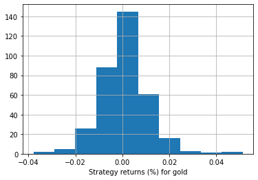

```python
df.strategy_returns_gold[split:].hist()
plt.xlabel('Strategy returns (%) for gold')
plt.show()
```

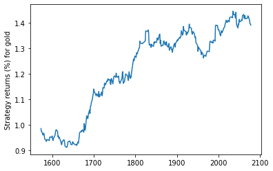

```python
(df.strategy_returns_gold[split:]+1).cumprod().plot()
plt.ylabel('Strategy returns (%) for gold')
plt.show()
```

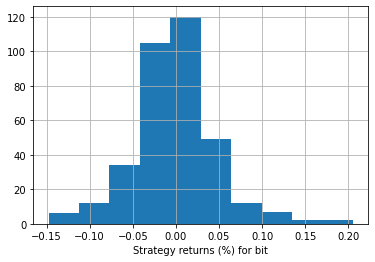

```python
df.strategy_returns_bit[split:].hist()
plt.xlabel('Strategy returns (%) for bit')
plt.show()
```

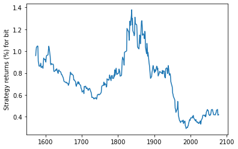

```python
(df.strategy_returns_bit[split:]+1).cumprod().plot()
plt.ylabel('Strategy returns (%) for bit')
plt.show()
```

```python
df.head()
```

|  | Date | bit | gold | pct_change_gold | pct_change_bit | std_5_gold | std_5_bit | std_30_gold | std_30_bit | ret_1_gold | ... | max_5_gold | max_5_bit | max_30_gold | max_30_bit | min_5_gold | min_5_bit | min_30_gold | min_30_bit | strategy_returns_gold | strategy_returns_bit |
| --- | --- | --- | --- | --- | --- | --- | --- | --- | --- | --- | --- | --- | --- | --- | --- | --- | --- | --- | --- | --- | --- |
| 45 | 2016-02-15 | 400.184998 | 1208.20 | -0.025449 | 0.041435 | 0.024760 | 0.017153 | 0.013339 | 0.044843 | -0.025449 | ... | 0.042857 | 0.041435 | 0.042857 | 0.105435 | -0.025449 | -0.005227 | -0.025449 | -0.153321 | 0.001076 | 0.018249 |
| 46 | 2016-02-16 | 407.488007 | 1209.50 | 0.001076 | 0.018249 | 0.024657 | 0.016719 | 0.013250 | 0.044989 | 0.001076 | ... | 0.042857 | 0.041435 | 0.042857 | 0.105435 | -0.025449 | -0.005227 | -0.025449 | -0.153321 | 0.000413 | 0.021679 |
| 47 | 2016-02-17 | 416.321991 | 1210.00 | 0.000413 | 0.021679 | 0.024610 | 0.016853 | 0.013144 | 0.045162 | 0.000413 | ... | 0.042857 | 0.041435 | 0.042857 | 0.105435 | -0.025449 | -0.005227 | -0.025449 | -0.153321 | 0.000083 | 0.014534 |
| 48 | 2016-02-18 | 422.372986 | 1210.10 | 0.000083 | 0.014534 | 0.011469 | 0.011663 | 0.013015 | 0.043437 | 0.000083 | ... | 0.001076 | 0.041435 | 0.042857 | 0.105435 | -0.025449 | 0.012140 | -0.025449 | -0.153321 | 0.017395 | -0.003760 |
| 49 | 2016-02-19 | 420.785004 | 1231.15 | 0.017395 | -0.003760 | 0.015355 | 0.016182 | 0.013197 | 0.043408 | 0.017395 | ... | 0.017395 | 0.041435 | 0.042857 | 0.105435 | -0.025449 | -0.003760 | -0.025449 | -0.153321 | 0.016367 | -0.040313 |

5 rows × 25 columns

Based on our assumption, we are going to buy bitcoin when `return of bitcoin - return of gold > 0.05`; buy 50%-50% bitcoin and gold when `-0.05 < return of bitcoin - return of gold < 0.05`; buy only gold when `return of bitcoin - return of gold < -0.05`

```python
df_decision = df[['strategy_returns_bit', 'strategy_returns_gold']]
df_decision['diff'] = df['strategy_returns_bit'] - df['strategy_returns_gold']
df_decision = df_decision.dropna()
```

```python
df_decision['decision'] = np.where(df_decision['diff'] > 0.05, 'Bitcoin','Gold')
```

```python
df_decision.loc[abs(df_decision['diff']) < 0.05, 'decision'] = 'Half-N-Half'
```

```python
df_decision
```

|  | strategy_returns_bit | strategy_returns_gold | diff | decision |
| --- | --- | --- | --- | --- |
| 45 | 0.018249 | 0.001076 | 0.017173 | Half-N-Half |
| 46 | 0.021679 | 0.000413 | 0.021266 | Half-N-Half |
| 47 | 0.014534 | 0.000083 | 0.014452 | Half-N-Half |
| 48 | -0.003760 | 0.017395 | -0.021155 | Half-N-Half |
| 49 | -0.040313 | 0.016367 | -0.056680 | Gold |
| ... | ... | ... | ... | ... |
| 2072 | 0.049465 | -0.001152 | 0.050616 | Bitcoin |
| 2075 | 0.017546 | -0.010677 | 0.028223 | Half-N-Half |
| 2076 | -0.111399 | -0.008962 | -0.102438 | Gold |
| 2077 | 0.015612 | -0.001260 | 0.016872 | Half-N-Half |
| 2078 | -0.006300 | -0.003551 | -0.002749 | Half-N-Half |

1399 rows × 4 columns

```python
df_result = pd.merge(df_decision,df, how='right')
```

```python
df_final = df_result[['Date','strategy_returns_bit','strategy_returns_gold','decision']]
df_final
```

|  | Date | strategy_returns_bit | strategy_returns_gold | decision |
| --- | --- | --- | --- | --- |
| 0 | 2016-02-15 | 0.018249 | 0.001076 | Half-N-Half |
| 1 | 2016-02-16 | 0.021679 | 0.000413 | Half-N-Half |
| 2 | 2016-02-17 | 0.014534 | 0.000083 | Half-N-Half |
| 3 | 2016-02-18 | -0.003760 | 0.017395 | Half-N-Half |
| 4 | 2016-02-19 | -0.040313 | 0.016367 | Gold |
| ... | ... | ... | ... | ... |
| 1395 | 2021-09-06 | 0.017546 | -0.010677 | Half-N-Half |
| 1396 | 2021-09-07 | -0.111399 | -0.008962 | Gold |
| 1397 | 2021-09-08 | 0.015612 | -0.001260 | Half-N-Half |
| 1398 | 2021-09-09 | -0.006300 | -0.003551 | Half-N-Half |
| 1399 | 2021-09-10 | NaN | NaN | NaN |

1400 rows × 4 columns

Therefore, we get our final result. If we add the commission fee in our calculation, then the condition should be `(return of bitcoin - alpha2) - (return of gold - alpha1) > 0.05`; buy 50%-50% bitcoin and gold when `-0.05 < (return of bitcoin - alpha2) - (return of gold - alpha1) < 0.05`; buy only gold when `(return of bitcoin - alpha2) - (return of gold - alpha1) < -0.05`

Additionaly, our return of each option will be `(return of bitcoin - alpha2)` for bitcoin; `(return of gold - alpha1)` for gold; and `(return of bitcoin - alpha2 + return of gold - alpha1)/2` for Half-N-Half. Since the value of alpha1, alpha2 did not specify, the formal code cannot be formulated.